# Motor Vehicle Accidents in New York City

In a developed city like New York, the competitive and fast-paced environment offers its own consequences. One of them is increased vehicular traffic and consequently, more accidents and crashes. While some accidents are inevitable, road safety and policies backed up by analysis can lead to apt suggestions about how to curb accidents or at least avoid them. This will be the core motivation of this project. In this report, we analyze the prevalence of vehicular accidents in NYC – their causes, effects and trends throughout the city. There will also be some recommendations about key insights for variables to consider that could shape future analysis.

```python
'''
Importing relevant libraries
'''
import pandas as pd
import seaborn as sns
import numpy as np
import plotly.express as px
import matplotlib.pyplot as plt
import plotly.graph_objects as go
```

## Reading and Storing Data

```python
'''
The dataset is present in the file mvc.csv
'''
data = pd.read_csv('mvc.csv', low_memory=False)
data.head(5)
```

|  | CRASH DATE | CRASH TIME | BOROUGH | ZIP CODE | LATITUDE | LONGITUDE | LOCATION | ON STREET NAME | CROSS STREET NAME | OFF STREET NAME | ... | CONTRIBUTING FACTOR VEHICLE 2 | CONTRIBUTING FACTOR VEHICLE 3 | CONTRIBUTING FACTOR VEHICLE 4 | CONTRIBUTING FACTOR VEHICLE 5 | COLLISION_ID | VEHICLE TYPE CODE 1 | VEHICLE TYPE CODE 2 | VEHICLE TYPE CODE 3 | VEHICLE TYPE CODE 4 | VEHICLE TYPE CODE 5 |
| --- | --- | --- | --- | --- | --- | --- | --- | --- | --- | --- | --- | --- | --- | --- | --- | --- | --- | --- | --- | --- | --- |
| 0 | 07/04/2018 | 12:20 | NaN | NaN | 40.723747 | -74.00612 | (40.723747, -74.00612) | VARICK STREET | NaN | NaN | ... | Aggressive Driving/Road Rage | NaN | NaN | NaN | 3934661 | Taxi | Station Wagon/Sport Utility Vehicle | NaN | NaN | NaN |
| 1 | 07/23/2018 | 16:30 | NaN | NaN | 40.822628 | -73.94351 | (40.822628, -73.94351) | WEST 144 STREET | NaN | NaN | ... | Unspecified | NaN | NaN | NaN | 3947774 | Station Wagon/Sport Utility Vehicle | NaN | NaN | NaN | NaN |
| 2 | 07/13/2018 | 15:40 | BROOKLYN | 11212 | 40.665146 | -73.90230 | (40.665146, -73.9023) | NaN | NaN | 455 DUMONT AVENUE | ... | Passing or Lane Usage Improper | NaN | NaN | NaN | 3943533 | Station Wagon/Sport Utility Vehicle | Bike | NaN | NaN | NaN |
| 3 | 07/25/2018 | 11:30 | BROOKLYN | 11211 | 40.713043 | -73.94467 | (40.713043, -73.94467) | NaN | NaN | 235 AINSLIE STREET | ... | NaN | NaN | NaN | NaN | 3949035 | Sedan | NaN | NaN | NaN | NaN |
| 4 | 07/05/2018 | 20:32 | BROOKLYN | 11207 | 40.658577 | -73.89063 | (40.658577, -73.89063) | PENNSYLVANIA AVENUE | LINDEN BOULEVARD | NaN | ... | Unspecified | NaN | NaN | NaN | 3936055 | Station Wagon/Sport Utility Vehicle | Sedan | NaN | NaN | NaN |

5 rows × 29 columns

Now that we have read the data, lets have a look at a small sample to familiarize ourselves with the data

```python
data.sample(5)
```

|  | CRASH DATE | CRASH TIME | BOROUGH | ZIP CODE | LATITUDE | LONGITUDE | LOCATION | ON STREET NAME | CROSS STREET NAME | OFF STREET NAME | ... | CONTRIBUTING FACTOR VEHICLE 2 | CONTRIBUTING FACTOR VEHICLE 3 | CONTRIBUTING FACTOR VEHICLE 4 | CONTRIBUTING FACTOR VEHICLE 5 | COLLISION_ID | VEHICLE TYPE CODE 1 | VEHICLE TYPE CODE 2 | VEHICLE TYPE CODE 3 | VEHICLE TYPE CODE 4 | VEHICLE TYPE CODE 5 |
| --- | --- | --- | --- | --- | --- | --- | --- | --- | --- | --- | --- | --- | --- | --- | --- | --- | --- | --- | --- | --- | --- |
| 1465769 | 05/05/2014 | 10:13 | BROOKLYN | 11217 | 40.683543 | -73.984374 | (40.6835431, -73.9843735) | WYCKOFF STREET | NEVINS STREET | NaN | ... | Unspecified | NaN | NaN | NaN | 336223 | NaN | NaN | NaN | NaN | NaN |
| 796009 | 06/09/2017 | 13:30 | NaN | NaN | 40.754524 | -73.723175 | (40.754524, -73.723175) | LITTLE NECK PARKWAY | GRAND CENTRAL PARKWAY | NaN | ... | Driver Inattention/Distraction | NaN | NaN | NaN | 3687330 | Sedan | Sedan | NaN | NaN | NaN |
| 298861 | 05/07/2019 | 11:47 | STATEN ISLAND | 10306 | 40.570126 | -74.109150 | (40.570126, -74.10915) | NaN | NaN | 430 NEW DORP LANE | ... | NaN | NaN | NaN | NaN | 4127467 | Station Wagon/Sport Utility Vehicle | NaN | NaN | NaN | NaN |
| 1747046 | 07/21/2012 | 19:30 | BRONX | 10457 | 40.846644 | -73.904688 | (40.846644, -73.9046882) | CLAY AVENUE | EAST 175 STREET | NaN | ... | Unspecified | NaN | NaN | NaN | 92206 | PASSENGER VEHICLE | PASSENGER VEHICLE | NaN | NaN | NaN |
| 488580 | 09/08/2018 | 8:05 | NaN | NaN | 40.742330 | -73.837640 | (40.74233, -73.83764) | VAN WYCK EXPWY | NaN | NaN | ... | NaN | NaN | NaN | NaN | 3976339 | Sedan | NaN | NaN | NaN | NaN |

5 rows × 29 columns

Lets have a look at the shape of the dataset and identify its granularity (i.e. what each row represents)

```python
data.shape
```

```
(1750704, 29)
```

The data has 1750704 rows and 29 columns.

- Each row pertains to a single motor vehicle accident in New York i.e., we have data for 1.7 million accidents which took place in New York City.
- Each column represents a feature about the motor vehicle accident record.

Now that we have looked at the shape and identified the granularity, its time to see in depth what columns we have - what they represent, their datatypes etc. Lets first enlist all the 29 columns

```python
data.columns
```

```
Index(['CRASH DATE', 'CRASH TIME', 'BOROUGH', 'ZIP CODE', 'LATITUDE',
       'LONGITUDE', 'LOCATION', 'ON STREET NAME', 'CROSS STREET NAME',
       'OFF STREET NAME', 'NUMBER OF PERSONS INJURED',
       'NUMBER OF PERSONS KILLED', 'NUMBER OF PEDESTRIANS INJURED',
       'NUMBER OF PEDESTRIANS KILLED', 'NUMBER OF CYCLIST INJURED',
       'NUMBER OF CYCLIST KILLED', 'NUMBER OF MOTORIST INJURED',
       'NUMBER OF MOTORIST KILLED', 'CONTRIBUTING FACTOR VEHICLE 1',
       'CONTRIBUTING FACTOR VEHICLE 2', 'CONTRIBUTING FACTOR VEHICLE 3',
       'CONTRIBUTING FACTOR VEHICLE 4', 'CONTRIBUTING FACTOR VEHICLE 5',
       'COLLISION_ID', 'VEHICLE TYPE CODE 1', 'VEHICLE TYPE CODE 2',
       'VEHICLE TYPE CODE 3', 'VEHICLE TYPE CODE 4', 'VEHICLE TYPE CODE 5'],
      dtype='object')
```

Now lets have a look at the data types of each column and check if we need to make any changes there

```python
data.dtypes
```

```
CRASH DATE                        object
CRASH TIME                        object
BOROUGH                           object
ZIP CODE                          object
LATITUDE                         float64
LONGITUDE                        float64
LOCATION                          object
ON STREET NAME                    object
CROSS STREET NAME                 object
OFF STREET NAME                   object
NUMBER OF PERSONS INJURED        float64
NUMBER OF PERSONS KILLED         float64
NUMBER OF PEDESTRIANS INJURED      int64
NUMBER OF PEDESTRIANS KILLED       int64
NUMBER OF CYCLIST INJURED          int64
NUMBER OF CYCLIST KILLED           int64
NUMBER OF MOTORIST INJURED         int64
NUMBER OF MOTORIST KILLED          int64
CONTRIBUTING FACTOR VEHICLE 1     object
CONTRIBUTING FACTOR VEHICLE 2     object
CONTRIBUTING FACTOR VEHICLE 3     object
CONTRIBUTING FACTOR VEHICLE 4     object
CONTRIBUTING FACTOR VEHICLE 5     object
COLLISION_ID                       int64
VEHICLE TYPE CODE 1               object
VEHICLE TYPE CODE 2               object
VEHICLE TYPE CODE 3               object
VEHICLE TYPE CODE 4               object
VEHICLE TYPE CODE 5               object
dtype: object
```

The data types for each feature seem fine. Therefore, no changes are required here.

Now finally, we will check the count and summary of values in each number column. This will just give us a brief idea of what the range of values is.

```python
data.describe()
```

|  | LATITUDE | LONGITUDE | NUMBER OF PERSONS INJURED | NUMBER OF PERSONS KILLED | NUMBER OF PEDESTRIANS INJURED | NUMBER OF PEDESTRIANS KILLED | NUMBER OF CYCLIST INJURED | NUMBER OF CYCLIST KILLED | NUMBER OF MOTORIST INJURED | NUMBER OF MOTORIST KILLED | COLLISION_ID |
| --- | --- | --- | --- | --- | --- | --- | --- | --- | --- | --- | --- |
| count | 1.542800e+06 | 1.542800e+06 | 1.750687e+06 | 1.750673e+06 | 1.750704e+06 | 1.750704e+06 | 1.750704e+06 | 1.750704e+06 | 1.750704e+06 | 1.750704e+06 | 1.750704e+06 |
| mean | 4.069042e+01 | -7.386765e+01 | 2.722029e-01 | 1.252661e-03 | 5.144216e-02 | 6.574498e-04 | 2.281254e-02 | 9.539020e-05 | 1.977821e-01 | 4.986565e-04 | 2.901809e+06 |
| std | 1.174742e+00 | 2.380661e+00 | 6.675508e-01 | 3.744185e-02 | 2.333444e-01 | 2.618354e-02 | 1.508962e-01 | 9.824640e-03 | 6.292408e-01 | 2.442651e-02 | 1.503069e+06 |
| min | 0.000000e+00 | -2.013600e+02 | 0.000000e+00 | 0.000000e+00 | 0.000000e+00 | 0.000000e+00 | 0.000000e+00 | 0.000000e+00 | 0.000000e+00 | 0.000000e+00 | 2.200000e+01 |
| 25% | 4.066865e+01 | -7.397614e+01 | 0.000000e+00 | 0.000000e+00 | 0.000000e+00 | 0.000000e+00 | 0.000000e+00 | 0.000000e+00 | 0.000000e+00 | 0.000000e+00 | 2.853509e+06 |
| 50% | 4.072224e+01 | -7.392851e+01 | 0.000000e+00 | 0.000000e+00 | 0.000000e+00 | 0.000000e+00 | 0.000000e+00 | 0.000000e+00 | 0.000000e+00 | 0.000000e+00 | 3.511508e+06 |
| 75% | 4.076880e+01 | -7.386667e+01 | 0.000000e+00 | 0.000000e+00 | 0.000000e+00 | 0.000000e+00 | 0.000000e+00 | 0.000000e+00 | 0.000000e+00 | 0.000000e+00 | 3.949420e+06 |
| max | 4.334444e+01 | 0.000000e+00 | 4.300000e+01 | 8.000000e+00 | 2.700000e+01 | 6.000000e+00 | 4.000000e+00 | 2.000000e+00 | 4.300000e+01 | 5.000000e+00 | 4.387521e+06 |

## Data Preprocessing

It is pretty obvious that with over 1.7 million records of accidents, each reading may not be 100% accurate. There may be missing values, outliers, redundant values and features and even inaccurate data. Therefore, before we begin our analysis, we will preprocess the data and clean it up in the best possible way. We have divided the process into multiple steps.

## 1. Finding Null Values

Lets check if there are any missing values in the data that we need to account for.

```python
print('Null Values In Each Column:')
data.isnull().sum()
```

```
Null Values In Each Column:
```

```
CRASH DATE                             0
CRASH TIME                             0
BOROUGH                           537299
ZIP CODE                          537510
LATITUDE                          207904
LONGITUDE                         207904
LOCATION                          207904
ON STREET NAME                    351938
CROSS STREET NAME                 613287
OFF STREET NAME                  1491134
NUMBER OF PERSONS INJURED             17
NUMBER OF PERSONS KILLED              31
NUMBER OF PEDESTRIANS INJURED          0
NUMBER OF PEDESTRIANS KILLED           0
NUMBER OF CYCLIST INJURED              0
NUMBER OF CYCLIST KILLED               0
NUMBER OF MOTORIST INJURED             0
NUMBER OF MOTORIST KILLED              0
CONTRIBUTING FACTOR VEHICLE 1       4907
CONTRIBUTING FACTOR VEHICLE 2     246619
CONTRIBUTING FACTOR VEHICLE 3    1633784
CONTRIBUTING FACTOR VEHICLE 4    1725617
CONTRIBUTING FACTOR VEHICLE 5    1744162
COLLISION_ID                           0
VEHICLE TYPE CODE 1                 9152
VEHICLE TYPE CODE 2               287366
VEHICLE TYPE CODE 3              1636915
VEHICLE TYPE CODE 4              1726316
VEHICLE TYPE CODE 5              1744335
dtype: int64
```

There are ALOT of Null values that we need to cater for. But lets take it column by column.

### Null Values in Latitude and Longitude

Since the data is based on location wise analysis of the accidents, it is important to know atleast one or more details about the location of the accident. We will have to drop the records where borough, longitude, latitude are NAN together. (since we know nothing about the location)

```python
final = data[(data['BOROUGH'].notnull() |  data['LONGITUDE'].notnull() |  data['LATITUDE'].notnull()) ]
data= final
```

We also drop the columns where latitude or longitude is not known at all. (This is because we can find unknown town from latitudes and longitudes but we cannot find the exact latitude and longitude from a given town). To avoid misinformation, we will remove all the Nan here

```python
data = data.dropna(subset=['LATITUDE', 'LONGITUDE'])
```

### Null Values in Borough

In some records of borough, we have latitudes and longitudes given but not the borough information. Lets try to find the missing boroughs from the latitude and longitudes.

For that, lets have a look at the list of boroughs in the data:

```python
b_list  = data.BOROUGH.unique()
print("List of unique boroughs: ", b_list)
```

```
List of unique boroughs:  [nan 'BROOKLYN' 'QUEENS' 'MANHATTAN' 'BRONX' 'STATEN ISLAND']
```

Before we change the Nan values, lets have a look of the accident count by borough. This will enable us to check whether the latitude and longitude actually help us predict the town or should we look for another approach

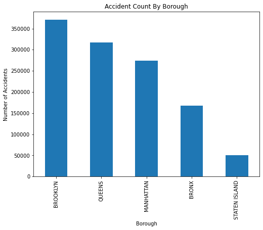

```python
b_list = b_list[1:]

plt.title("Accident Count By Borough")
ax = data['BOROUGH'].value_counts()
ax.plot.bar(figsize=(8,6))
plt.xlabel("Borough")
plt.ylabel("Number of Accidents")
plt.show()
```

```python
'''
borough_group = data.groupby(['BOROUGH'])

la = borough_group['LATITUDE'].mean()
lo = borough_group['LONGITUDE'].mean()

dict_la = {}
dict_lo = {}

for town in b_list:
    dict_la[town] = la[town]
    dict_lo[town] = lo[town]

dfnew = data[data['BOROUGH'].isna()]

from collections import Counter

d1 = {}
d2 = {}


for i in dict_la:
    d1[i] = abs(dfnew['LATITUDE'] - dict_la[i])

for i in dict_lo:
    d2[i] = abs(dfnew['LONGITUDE'] - dict_lo[i])

d = {}
e = {}
for ind, row in dfnew.iterrows():
    for i in d1:
        d[i] = (d1[i])[ind]

    for i in d2:
        e[i] = d2[i][ind]

    a = Counter(d)
    b = Counter(e)

    added = a + b
    combined = dict(added)

    key_min1 = min(combined.keys(), key=(lambda k: combined[k]))

    data.loc[ind, 'BOROUGH'] = key_min1
'''
```

```
"\nborough_group = data.groupby(['BOROUGH'])\n\nla = borough_group['LATITUDE'].mean()\nlo = borough_group['LONGITUDE'].mean()\n\ndict_la = {}\ndict_lo = {}\n\nfor town in b_list:\n    dict_la[town] = la[town]\n    dict_lo[town] = lo[town]\n\ndfnew = data[data['BOROUGH'].isna()]\n\nfrom collections i…
```

We tried to find the boroughs using latitudes and longitudes but it results in unpredictible results i.e, boroughs which had higher accident count first moved to lower places resulting in potentially biased side. Therefore, instead of filling the data with uncertain values, we just drop the null records.

```python
data = data.dropna(subset=['BOROUGH'])
```

### Null Values in Street Name

We have three street names given - ON STREET NAME, OFF STREET NAME and CROSS STREET NAME. Since some of them are null and some are not, we decide to keep ON STREET NAME and merge the rest in order of decreasing priority. This forms a new column STREET NAME which gives us an idea about the street (without further sub divisions in categories)

```python
cond = data['ON STREET NAME'].isna()
data['ON STREET NAME'] = np.where(cond, data['CROSS STREET NAME'], data['ON STREET NAME'])


cond = data['ON STREET NAME'].isna()
data['ON STREET NAME'] = np.where(cond, data['OFF STREET NAME'], data['ON STREET NAME'])

data = data.rename(columns={"ON STREET NAME":"STREET NAME"})

data = data.drop(columns=['OFF STREET NAME', 'CROSS STREET NAME'])
```

In case there is absolutely no information about street names, we fill it with unknown/unspecified. We chose not to drop the rows solely based on streets, because we do have valuable information about the latitudes, longitudes and boroughs.

```python
data[['STREET NAME']] = data[['STREET NAME']].fillna(value="UNSPECIFIED")
```

### Null Values in Persons Injured and Persons Killed

The NULL values in these columns are negligible but filling them with mode, mean, median or any value means introducing potential discrepancy in a sensitive content like 'death' and 'injuries'. Thus, these columns are supposed to be accurate for our interpretation so we drop NAN rows of persons injured and number of persons killed.

```python
data.dropna(subset=['NUMBER OF PERSONS INJURED', 'NUMBER OF PERSONS KILLED'], inplace=True)
```

### Null Values in Vehicle 3,4,5 and Contributing Factors

Vehicle Type 1 and 2 (along with their contributing factors) seemed more usable with less Nan and faulty values. Therefore, we will be dropping Vehicle 3,4,5 and their contributing factors because we have decided to use Vehicle 1 and 2 for our analysis.

```python
data.drop(['VEHICLE TYPE CODE 3','VEHICLE TYPE CODE 4','VEHICLE TYPE CODE 5', 'CONTRIBUTING FACTOR VEHICLE 3','CONTRIBUTING FACTOR VEHICLE 4','CONTRIBUTING FACTOR VEHICLE 5'],
  axis='columns', inplace=True)

data = pd.DataFrame(data)
```

### Null Values in Vehicle 1,2 Contributing Factors

Depsite being useable overall, there were still a few Null values in Vehicle 1 and 2 and their respective contributing factors. We will not drop them. Instead we fill null vals of CONTRIBUTING FACTOR VEHICLE 1,CONTRIBUTING FACTOR VEHICLE 2 with 'unspecified'

```python
contributing_factor = ['CONTRIBUTING FACTOR VEHICLE 1','CONTRIBUTING FACTOR VEHICLE 2']
for column in contributing_factor:
    data[column].fillna('unspecified', inplace=True)
```

### Null Values in Vehicle Code 1 and 2

```python
col = ['VEHICLE TYPE CODE 1', 'VEHICLE TYPE CODE 2']
for column in col:
    data[column].fillna(data[column].mode()[0], inplace=True)
```

### Null Values in Zip Code

In cases where zip code were missing, we used a different strategy and filled the Nan values in the missing zipcodes with the mode of that particular borough's zipcode.

```python
data['ZIP CODE'] = data.groupby(['BOROUGH'], sort=False)['ZIP CODE'].apply(lambda x: x.fillna(x.mode().iloc[0]))
```

We have tried to cater for Null values in each feature. Lets check the final count of Null values (after cleaning)

```python
print('Null Values In Each Column:')
data.isnull().sum()
```

```
Null Values In Each Column:
```

```
CRASH DATE                       0
CRASH TIME                       0
BOROUGH                          0
ZIP CODE                         0
LATITUDE                         0
LONGITUDE                        0
LOCATION                         0
STREET NAME                      0
NUMBER OF PERSONS INJURED        0
NUMBER OF PERSONS KILLED         0
NUMBER OF PEDESTRIANS INJURED    0
NUMBER OF PEDESTRIANS KILLED     0
NUMBER OF CYCLIST INJURED        0
NUMBER OF CYCLIST KILLED         0
NUMBER OF MOTORIST INJURED       0
NUMBER OF MOTORIST KILLED        0
CONTRIBUTING FACTOR VEHICLE 1    0
CONTRIBUTING FACTOR VEHICLE 2    0
COLLISION_ID                     0
VEHICLE TYPE CODE 1              0
VEHICLE TYPE CODE 2              0
dtype: int64
```

As evident from the null value counts from above, now our data does not have any Null values! Its time to move towards other aspects of data cleaning.

## Dealing With Redundant Features

When we were analyzing the features one by one, we saw that there was one redundant feature. The **location** feature is an ordered pair of latitude and longitude. Since this information is redundant, we can drop it and use the other columns when needed.

```python
data.drop(['LOCATION'], axis='columns', inplace=True)
data = pd.DataFrame(data)
```

## Standardizing the Data

### Setting Index

```python
data = data.set_index('COLLISION_ID')
#data.head(5)
```

### Lower Case

Although this does not impact our analysis in a significant way, having the columns in a similar format makes the data easily interpretable and usable. Therefore, we decided to convert all the the column strings to lowercase.

```python
data = data.applymap(lambda s:s.lower() if type(s) == str else s)
```

### Columns for Date

```python
data['MONTH'] = pd.DatetimeIndex(data['CRASH DATE']).month
data['DATE'] = pd.DatetimeIndex(data['CRASH DATE']).day
data['YEAR'] = pd.DatetimeIndex(data['CRASH DATE']).year
```

## Overview of the Cleaned Data

Now that we have dealt with all Null, Redundant and Unusable data, lets have a look at the cleaned data, its shape and features

```python
data.shape
```

```
(1181999, 22)
```

```python
data.sample(5)
```

| COLLISION_ID | CRASH DATE | CRASH TIME | BOROUGH | ZIP CODE | LATITUDE | LONGITUDE | STREET NAME | NUMBER OF PERSONS INJURED | NUMBER OF PERSONS KILLED | NUMBER OF PEDESTRIANS INJURED | ... | NUMBER OF CYCLIST KILLED | NUMBER OF MOTORIST INJURED | NUMBER OF MOTORIST KILLED | CONTRIBUTING FACTOR VEHICLE 1 | CONTRIBUTING FACTOR VEHICLE 2 | VEHICLE TYPE CODE 1 | VEHICLE TYPE CODE 2 | MONTH | DATE | YEAR |
| --- | --- | --- | --- | --- | --- | --- | --- | --- | --- | --- | --- | --- | --- | --- | --- | --- | --- | --- | --- | --- | --- |
| 346471 | 06/05/2014 | 17:45 | manhattan | 10007 | 40.711016 | -74.010800 | church street | 0.0 | 0.0 | 0 | ... | 0 | 0 | 0 | unspecified | unspecified | bus | passenger vehicle | 6 | 5 | 2014 |
| 173537 | 01/19/2013 | 10:57 | brooklyn | 11216 | 40.669712 | -73.947730 | eastern parkway | 0.0 | 0.0 | 0 | ... | 0 | 0 | 0 | unspecified | unspecified | passenger vehicle | passenger vehicle | 1 | 19 | 2013 |
| 79381 | 02/16/2013 | 22:20 | bronx | 10460 | 40.834918 | -73.894124 | wilkens avenue | 0.0 | 0.0 | 0 | ... | 0 | 0 | 0 | prescription medication | unspecified | passenger vehicle | passenger vehicle | 2 | 16 | 2013 |
| 4048031 | 12/19/2018 | 8:28 | brooklyn | 11209 | 40.619960 | -74.023660 | 86 street | 0.0 | 0.0 | 0 | ... | 0 | 0 | 0 | oversized vehicle | unspecified | box truck | sedan | 12 | 19 | 2018 |
| 3473754 | 07/03/2016 | 10:00 | brooklyn | 11204 | 40.614655 | -73.979630 | 2217 63 street | 0.0 | 0.0 | 0 | ... | 0 | 0 | 0 | unspecified | unspecified | 4 dr sedan | passenger vehicle | 7 | 3 | 2016 |

5 rows × 22 columns

```python
data.describe()
```

|  | LATITUDE | LONGITUDE | NUMBER OF PERSONS INJURED | NUMBER OF PERSONS KILLED | NUMBER OF PEDESTRIANS INJURED | NUMBER OF PEDESTRIANS KILLED | NUMBER OF CYCLIST INJURED | NUMBER OF CYCLIST KILLED | NUMBER OF MOTORIST INJURED | NUMBER OF MOTORIST KILLED | MONTH | DATE | YEAR |
| --- | --- | --- | --- | --- | --- | --- | --- | --- | --- | --- | --- | --- | --- |
| count | 1.181999e+06 | 1.181999e+06 | 1.181999e+06 | 1.181999e+06 | 1.181999e+06 | 1.181999e+06 | 1.181999e+06 | 1.181999e+06 | 1.181999e+06 | 1.181999e+06 | 1.181999e+06 | 1.181999e+06 | 1.181999e+06 |
| mean | 4.068879e+01 | -7.386067e+01 | 2.598166e-01 | 1.129443e-03 | 6.046536e-02 | 6.531308e-04 | 2.600341e-02 | 9.560076e-05 | 1.731677e-01 | 3.781729e-04 | 6.738347e+00 | 1.562282e+01 | 2.015897e+03 |
| std | 1.176497e+00 | 2.132506e+00 | 6.410317e-01 | 3.568871e-02 | 2.522465e-01 | 2.626652e-02 | 1.606217e-01 | 9.863252e-03 | 5.913763e-01 | 2.131132e-02 | 3.439544e+00 | 8.747584e+00 | 2.358876e+00 |
| min | 0.000000e+00 | -7.425453e+01 | 0.000000e+00 | 0.000000e+00 | 0.000000e+00 | 0.000000e+00 | 0.000000e+00 | 0.000000e+00 | 0.000000e+00 | 0.000000e+00 | 1.000000e+00 | 1.000000e+00 | 2.012000e+03 |
| 25% | 4.066739e+01 | -7.397765e+01 | 0.000000e+00 | 0.000000e+00 | 0.000000e+00 | 0.000000e+00 | 0.000000e+00 | 0.000000e+00 | 0.000000e+00 | 0.000000e+00 | 4.000000e+00 | 8.000000e+00 | 2.014000e+03 |
| 50% | 4.071993e+01 | -7.393127e+01 | 0.000000e+00 | 0.000000e+00 | 0.000000e+00 | 0.000000e+00 | 0.000000e+00 | 0.000000e+00 | 0.000000e+00 | 0.000000e+00 | 7.000000e+00 | 1.600000e+01 | 2.016000e+03 |
| 75% | 4.076587e+01 | -7.387121e+01 | 0.000000e+00 | 0.000000e+00 | 0.000000e+00 | 0.000000e+00 | 0.000000e+00 | 0.000000e+00 | 0.000000e+00 | 0.000000e+00 | 1.000000e+01 | 2.300000e+01 | 2.018000e+03 |
| max | 4.112615e+01 | 0.000000e+00 | 4.300000e+01 | 8.000000e+00 | 2.700000e+01 | 6.000000e+00 | 4.000000e+00 | 2.000000e+00 | 4.300000e+01 | 5.000000e+00 | 1.200000e+01 | 3.100000e+01 | 2.021000e+03 |

Lets find the number of distinct values in each feature of the dataset so that we know what to expect next:

```python
data.nunique(axis=0)
```

```
CRASH DATE                         3132
CRASH TIME                         1440
BOROUGH                               5
ZIP CODE                            232
LATITUDE                         111008
LONGITUDE                         85449
STREET NAME                      145220
NUMBER OF PERSONS INJURED            26
NUMBER OF PERSONS KILLED              7
NUMBER OF PEDESTRIANS INJURED        12
NUMBER OF PEDESTRIANS KILLED          4
NUMBER OF CYCLIST INJURED             5
NUMBER OF CYCLIST KILLED              3
NUMBER OF MOTORIST INJURED           26
NUMBER OF MOTORIST KILLED             6
CONTRIBUTING FACTOR VEHICLE 1        59
CONTRIBUTING FACTOR VEHICLE 2        58
VEHICLE TYPE CODE 1                 644
VEHICLE TYPE CODE 2                 679
MONTH                                12
DATE                                 31
YEAR                                 10
dtype: int64
```

An interesting feature is the column that we created ourselves i.e, year. We have data from 10 years. Lets have a look at what they are:

```python
unique_years = (pd.unique(data['YEAR']))
print(unique_years)
```

```
[2018 2019 2021 2017 2020 2013 2016 2015 2014 2012]
```

So we have data from 2012 to 2021. Lets use this data to try to find interesting trends focusing on (but not limited )time and region based analysis of accidents in New York city.

# Frequent Pattern Mining

After cleaning the data and applying exploratory data analysis, we got hold of multiple interesting findings about the collisions in New York City. While we did find a lot of trends and patterns through the visualizations and summaries in the EDA, let us confirm them in this section using frequent pattern mining techniques.

## Overview of the data

Let us have a look at the dataset first. This is the cleaned data that we found out earlier

```python
data.head()
```

| COLLISION_ID | CRASH DATE | CRASH TIME | BOROUGH | ZIP CODE | LATITUDE | LONGITUDE | STREET NAME | NUMBER OF PERSONS INJURED | NUMBER OF PERSONS KILLED | NUMBER OF PEDESTRIANS INJURED | ... | NUMBER OF CYCLIST KILLED | NUMBER OF MOTORIST INJURED | NUMBER OF MOTORIST KILLED | CONTRIBUTING FACTOR VEHICLE 1 | CONTRIBUTING FACTOR VEHICLE 2 | VEHICLE TYPE CODE 1 | VEHICLE TYPE CODE 2 | MONTH | DATE | YEAR |
| --- | --- | --- | --- | --- | --- | --- | --- | --- | --- | --- | --- | --- | --- | --- | --- | --- | --- | --- | --- | --- | --- |
| 3943533 | 07/13/2018 | 15:40 | brooklyn | 11212 | 40.665146 | -73.90230 | 455 dumont avenue | 1.0 | 0.0 | 0 | ... | 0 | 0 | 0 | failure to yield right-of-way | passing or lane usage improper | station wagon/sport utility vehicle | bike | 7 | 13 | 2018 |
| 3949035 | 07/25/2018 | 11:30 | brooklyn | 11211 | 40.713043 | -73.94467 | 235 ainslie street | 0.0 | 0.0 | 0 | ... | 0 | 0 | 0 | unspecified | unspecified | sedan | passenger vehicle | 7 | 25 | 2018 |
| 3936055 | 07/05/2018 | 20:32 | brooklyn | 11207 | 40.658577 | -73.89063 | pennsylvania avenue | 2.0 | 0.0 | 0 | ... | 0 | 2 | 0 | failure to yield right-of-way | unspecified | station wagon/sport utility vehicle | sedan | 7 | 5 | 2018 |
| 3948971 | 07/26/2018 | 12:39 | queens | 11691 | 40.596230 | -73.75412 | 252 beach 20 street | 0.0 | 0.0 | 0 | ... | 0 | 0 | 0 | following too closely | unspecified | tractor truck diesel | station wagon/sport utility vehicle | 7 | 26 | 2018 |
| 3933446 | 07/02/2018 | 7:40 | queens | 11372 | 40.748337 | -73.89391 | 37-23 72 street | 1.0 | 0.0 | 0 | ... | 0 | 1 | 0 | driver inattention/distraction | unspecified | station wagon/sport utility vehicle | station wagon/sport utility vehicle | 7 | 2 | 2018 |

5 rows × 22 columns

Now lets have a look at the columns out of which we will be needing particular features to carry out frequent pattern mining.

```python
data.columns
```

```
Index(['CRASH DATE', 'CRASH TIME', 'BOROUGH', 'ZIP CODE', 'LATITUDE',
       'LONGITUDE', 'STREET NAME', 'NUMBER OF PERSONS INJURED',
       'NUMBER OF PERSONS KILLED', 'NUMBER OF PEDESTRIANS INJURED',
       'NUMBER OF PEDESTRIANS KILLED', 'NUMBER OF CYCLIST INJURED',
       'NUMBER OF CYCLIST KILLED', 'NUMBER OF MOTORIST INJURED',
       'NUMBER OF MOTORIST KILLED', 'CONTRIBUTING FACTOR VEHICLE 1',
       'CONTRIBUTING FACTOR VEHICLE 2', 'VEHICLE TYPE CODE 1',
       'VEHICLE TYPE CODE 2', 'MONTH', 'DATE', 'YEAR'],
      dtype='object')
```

## Feature Selection and Extraction

In order to make sure that we are using the correct features for frequent pattern mining i.e., features that give meaningful results, we have to go feature by feature, determine its importance and effectiveness in frequent pattern minining and then engineer it accordingly. Lets go featre by feature.

### Feature Selection

```python
fpm_df = data.copy()
fpm_df = fpm_df.drop(['CRASH DATE', 'DATE', 'LATITUDE', 'LONGITUDE', 'STREET NAME'], axis=1)
```

### Feature Extraction

```python
TIME = fpm_df['CRASH TIME'].astype('datetime64[ns]')
fpm_df['HOUR'] = pd.DatetimeIndex(TIME).hour

fpm_df["TIME"] = fpm_df["HOUR"]

fpm_df.loc[(fpm_df.HOUR < 12),'TIME']='Before 12PM'
fpm_df.loc[(fpm_df.HOUR > 18),'TIME']='After 6PM'
fpm_df.loc[((fpm_df.HOUR >= 12) & (fpm_df.HOUR < 15)),'TIME']='12PM to 3PM'
fpm_df.loc[((fpm_df.HOUR >= 15) & (fpm_df.HOUR < 18)),'TIME']='3PM to 6PM'

fpm_df.head()
```

| COLLISION_ID | CRASH TIME | BOROUGH | ZIP CODE | NUMBER OF PERSONS INJURED | NUMBER OF PERSONS KILLED | NUMBER OF PEDESTRIANS INJURED | NUMBER OF PEDESTRIANS KILLED | NUMBER OF CYCLIST INJURED | NUMBER OF CYCLIST KILLED | NUMBER OF MOTORIST INJURED | NUMBER OF MOTORIST KILLED | CONTRIBUTING FACTOR VEHICLE 1 | CONTRIBUTING FACTOR VEHICLE 2 | VEHICLE TYPE CODE 1 | VEHICLE TYPE CODE 2 | MONTH | YEAR | HOUR | TIME |
| --- | --- | --- | --- | --- | --- | --- | --- | --- | --- | --- | --- | --- | --- | --- | --- | --- | --- | --- | --- |
| 3943533 | 15:40 | brooklyn | 11212 | 1.0 | 0.0 | 0 | 0 | 1 | 0 | 0 | 0 | failure to yield right-of-way | passing or lane usage improper | station wagon/sport utility vehicle | bike | 7 | 2018 | 15 | 3PM to 6PM |
| 3949035 | 11:30 | brooklyn | 11211 | 0.0 | 0.0 | 0 | 0 | 0 | 0 | 0 | 0 | unspecified | unspecified | sedan | passenger vehicle | 7 | 2018 | 11 | Before 12PM |
| 3936055 | 20:32 | brooklyn | 11207 | 2.0 | 0.0 | 0 | 0 | 0 | 0 | 2 | 0 | failure to yield right-of-way | unspecified | station wagon/sport utility vehicle | sedan | 7 | 2018 | 20 | After 6PM |
| 3948971 | 12:39 | queens | 11691 | 0.0 | 0.0 | 0 | 0 | 0 | 0 | 0 | 0 | following too closely | unspecified | tractor truck diesel | station wagon/sport utility vehicle | 7 | 2018 | 12 | 12PM to 3PM |
| 3933446 | 7:40 | queens | 11372 | 1.0 | 0.0 | 0 | 0 | 0 | 0 | 1 | 0 | driver inattention/distraction | unspecified | station wagon/sport utility vehicle | station wagon/sport utility vehicle | 7 | 2018 | 7 | Before 12PM |

Since we have made the desired column for time, we can drop the rest of time

```python
fpm_df = fpm_df.drop(['CRASH TIME', 'HOUR'], axis=1)
```

Now we will modify the month column from numbers (month-wise) to the actual names so that it is easy to interpet

```python
fpm_df['MONTH'] = pd.to_datetime(fpm_df['MONTH'], format='%m').dt.month_name().str.slice(stop=3)
```

### Feature Modification

To increase the interpretability of the the frequent patterns that we may get through the process, lets add key words to the necessary columns.

```python
fpm_df['NUMBER OF MOTORIST KILLED'] = 'MK:' + fpm_df['NUMBER OF MOTORIST KILLED'].astype(str)
fpm_df['NUMBER OF MOTORIST INJURED'] = 'MI:' + fpm_df['NUMBER OF MOTORIST INJURED'].astype(str)
fpm_df['NUMBER OF CYCLIST KILLED'] = 'CK:' + fpm_df['NUMBER OF CYCLIST KILLED'].astype(str)
fpm_df['NUMBER OF CYCLIST INJURED'] = 'CI:' + fpm_df['NUMBER OF CYCLIST INJURED'].astype(str)
fpm_df['NUMBER OF PEDESTRIANS KILLED'] = 'PedK:' + fpm_df['NUMBER OF PEDESTRIANS KILLED'].astype(str)
fpm_df['NUMBER OF PEDESTRIANS INJURED'] = 'PedI:' + fpm_df['NUMBER OF PEDESTRIANS INJURED'].astype(str)
fpm_df['NUMBER OF PERSONS KILLED'] = 'PK:' + fpm_df['NUMBER OF PERSONS KILLED'].astype(str)
fpm_df['NUMBER OF PERSONS INJURED'] = 'PI:' + fpm_df['NUMBER OF PERSONS INJURED'].astype(str)
fpm_df['VEHICLE TYPE CODE 1'] = 'V1:' + fpm_df['VEHICLE TYPE CODE 1'].astype(str)
fpm_df['VEHICLE TYPE CODE 2'] = 'V2:' + fpm_df['VEHICLE TYPE CODE 2'].astype(str)

fpm_df.head()
```

| COLLISION_ID | BOROUGH | ZIP CODE | NUMBER OF PERSONS INJURED | NUMBER OF PERSONS KILLED | NUMBER OF PEDESTRIANS INJURED | NUMBER OF PEDESTRIANS KILLED | NUMBER OF CYCLIST INJURED | NUMBER OF CYCLIST KILLED | NUMBER OF MOTORIST INJURED | NUMBER OF MOTORIST KILLED | CONTRIBUTING FACTOR VEHICLE 1 | CONTRIBUTING FACTOR VEHICLE 2 | VEHICLE TYPE CODE 1 | VEHICLE TYPE CODE 2 | MONTH | YEAR | TIME |
| --- | --- | --- | --- | --- | --- | --- | --- | --- | --- | --- | --- | --- | --- | --- | --- | --- | --- |
| 3943533 | brooklyn | 11212 | PI:1.0 | PK:0.0 | PedI:0 | PedK:0 | CI:1 | CK:0 | MI:0 | MK:0 | failure to yield right-of-way | passing or lane usage improper | V1:station wagon/sport utility vehicle | V2:bike | Jul | 2018 | 3PM to 6PM |
| 3949035 | brooklyn | 11211 | PI:0.0 | PK:0.0 | PedI:0 | PedK:0 | CI:0 | CK:0 | MI:0 | MK:0 | unspecified | unspecified | V1:sedan | V2:passenger vehicle | Jul | 2018 | Before 12PM |
| 3936055 | brooklyn | 11207 | PI:2.0 | PK:0.0 | PedI:0 | PedK:0 | CI:0 | CK:0 | MI:2 | MK:0 | failure to yield right-of-way | unspecified | V1:station wagon/sport utility vehicle | V2:sedan | Jul | 2018 | After 6PM |
| 3948971 | queens | 11691 | PI:0.0 | PK:0.0 | PedI:0 | PedK:0 | CI:0 | CK:0 | MI:0 | MK:0 | following too closely | unspecified | V1:tractor truck diesel | V2:station wagon/sport utility vehicle | Jul | 2018 | 12PM to 3PM |
| 3933446 | queens | 11372 | PI:1.0 | PK:0.0 | PedI:0 | PedK:0 | CI:0 | CK:0 | MI:1 | MK:0 | driver inattention/distraction | unspecified | V1:station wagon/sport utility vehicle | V2:station wagon/sport utility vehicle | Jul | 2018 | Before 12PM |

In order to covert the dataframe to transactions and perform FPM, we will convert the datatype of the dataframe's columns to strings

```python
fpm_df = fpm_df.astype(str)
fpm_df.dtypes
```

```
BOROUGH                          object
ZIP CODE                         object
NUMBER OF PERSONS INJURED        object
NUMBER OF PERSONS KILLED         object
NUMBER OF PEDESTRIANS INJURED    object
NUMBER OF PEDESTRIANS KILLED     object
NUMBER OF CYCLIST INJURED        object
NUMBER OF CYCLIST KILLED         object
NUMBER OF MOTORIST INJURED       object
NUMBER OF MOTORIST KILLED        object
CONTRIBUTING FACTOR VEHICLE 1    object
CONTRIBUTING FACTOR VEHICLE 2    object
VEHICLE TYPE CODE 1              object
VEHICLE TYPE CODE 2              object
MONTH                            object
YEAR                             object
TIME                             object
dtype: object
```

Before we move on to the main part - frequent pattern mining, lets have a look at the data and features that we will be using for FPM

```python
fpm_df.head(5)
```

| COLLISION_ID | BOROUGH | ZIP CODE | NUMBER OF PERSONS INJURED | NUMBER OF PERSONS KILLED | NUMBER OF PEDESTRIANS INJURED | NUMBER OF PEDESTRIANS KILLED | NUMBER OF CYCLIST INJURED | NUMBER OF CYCLIST KILLED | NUMBER OF MOTORIST INJURED | NUMBER OF MOTORIST KILLED | CONTRIBUTING FACTOR VEHICLE 1 | CONTRIBUTING FACTOR VEHICLE 2 | VEHICLE TYPE CODE 1 | VEHICLE TYPE CODE 2 | MONTH | YEAR | TIME |
| --- | --- | --- | --- | --- | --- | --- | --- | --- | --- | --- | --- | --- | --- | --- | --- | --- | --- |
| 3943533 | brooklyn | 11212 | PI:1.0 | PK:0.0 | PedI:0 | PedK:0 | CI:1 | CK:0 | MI:0 | MK:0 | failure to yield right-of-way | passing or lane usage improper | V1:station wagon/sport utility vehicle | V2:bike | Jul | 2018 | 3PM to 6PM |
| 3949035 | brooklyn | 11211 | PI:0.0 | PK:0.0 | PedI:0 | PedK:0 | CI:0 | CK:0 | MI:0 | MK:0 | unspecified | unspecified | V1:sedan | V2:passenger vehicle | Jul | 2018 | Before 12PM |
| 3936055 | brooklyn | 11207 | PI:2.0 | PK:0.0 | PedI:0 | PedK:0 | CI:0 | CK:0 | MI:2 | MK:0 | failure to yield right-of-way | unspecified | V1:station wagon/sport utility vehicle | V2:sedan | Jul | 2018 | After 6PM |
| 3948971 | queens | 11691 | PI:0.0 | PK:0.0 | PedI:0 | PedK:0 | CI:0 | CK:0 | MI:0 | MK:0 | following too closely | unspecified | V1:tractor truck diesel | V2:station wagon/sport utility vehicle | Jul | 2018 | 12PM to 3PM |
| 3933446 | queens | 11372 | PI:1.0 | PK:0.0 | PedI:0 | PedK:0 | CI:0 | CK:0 | MI:1 | MK:0 | driver inattention/distraction | unspecified | V1:station wagon/sport utility vehicle | V2:station wagon/sport utility vehicle | Jul | 2018 | Before 12PM |

## Transactions

Now we find the transactions. For this we make a resuables function

```python
def transactionsfunc(df):
    transactions = df.to_numpy()
    return transactions

transactions = transactionsfunc(fpm_df)
transactions
```

```
array([['brooklyn', '11212', 'PI:1.0', ..., 'Jul', '2018', '3PM to 6PM'],
       ['brooklyn', '11211', 'PI:0.0', ..., 'Jul', '2018', 'Before 12PM'],
       ['brooklyn', '11207', 'PI:2.0', ..., 'Jul', '2018', 'After 6PM'],
       ...,
       ['brooklyn', '11218', 'PI:0.0', ..., 'Jul', '2012', 'Before 12PM'],
       ['brooklyn', '11238', 'PI:1.0', ..., 'Jul', '2012', 'After 6PM'],
       ['brooklyn', '11206', 'PI:3.0', ..., 'Jul', '2012', '12PM to 3PM']],
      dtype=object)
```

```python
transactions.shape
```

```
(1181999, 17)
```

## Apriori and FP-Growth

```python
# Using library implementation of Apriori Algorithm
from apyori import apriori

def apriori_alg(transactions, minimum_support):
    ret_dict = {}
    frequent_itemsets = apriori(transactions, min_support = minimum_support)
    frequent_itemsets = list(frequent_itemsets)
    freq_itemsets = [(list(frequent_itemsets[i][0]),frequent_itemsets[i][1]) for i in range(len(frequent_itemsets))]

    for (s, support) in freq_itemsets:
        ret_dict[tuple(s)] = int(support*len(transactions))

    #return freq_itemsets
    return ret_dict

def apriori_algo(transactions, minimum_support,minimum_length):
    # Make frequent patterns
    freq_patterns  = apriori_alg(transactions, minimum_support)

    # Choose frequent pattern of required length (or greater)
    temp = freq_patterns.copy()
    for i in temp:
        if len(i) < minimum_length:
            freq_patterns.pop(i)

    return freq_patterns

def freqitemset_list(freqitemset_dictionary):
    freq_pattern = []
    for tup in freqitemset_dictionary.keys():
        freq_pattern.append(list(tup))

    return freq_pattern

# How to use
# minimum_support = 0.7
# minimum_length = 3
# freq_patterns  = apriori_algo(transactions, minimum_support, minimum_length)
# freq_pattern = freqitemset_list(freq_patterns)

# print("- List of Frequent Itemsets: ", freq_pattern, "\n")
# print("- Frequent Itemsets: ", freq_patterns, "\n")
```

```python
import pyfpgrowth

def fp_growth(transactions, minimum_support):
    patterns = pyfpgrowth.find_frequent_patterns(transactions,minimum_support*len(transactions))
    return patterns

def fp_growth_len(transactions, minimum_support,minimum_length):
    # Make frequent patterns
    freq_patterns  = fp_growth(transactions, minimum_support)

    # Choose frequent pattern of required length (or greater)
    temp = freq_patterns.copy()
    for i in temp:
        if len(i) < minimum_length:
            freq_patterns.pop(i)

    return freq_patterns


# How to use
# minimum_support = 0.7
# freq_patterns  = fp_growth(transactions, minimum_support)
# freq_pattern = freqitemset_list(freq_patterns)

# print("- List of Frequent Itemsets: ", freq_pattern, "\n")
# print("- Frequent Itemsets: ", freq_patterns, "\n")
```

```python
# Convert freq pattern dictionary to dataframe. I dont think we will need it
# d = freq_patterns
# df = pd.DataFrame(d.items(), columns=['itemsets', 'support'])
# df
```

```python
df = data.copy()
df_new = fpm_df[(df['NUMBER OF PERSONS INJURED'] > 0) | (df['NUMBER OF PERSONS KILLED'] > 0)]
df_new = df_new.drop(columns=['NUMBER OF CYCLIST KILLED', 'NUMBER OF CYCLIST INJURED','NUMBER OF MOTORIST INJURED', 'NUMBER OF PEDESTRIANS INJURED', 'NUMBER OF MOTORIST KILLED', 'NUMBER OF PEDESTRIANS KILLED', 'CONTRIBUTING FACTOR VEHICLE 1', 'CONTRIBUTING FACTOR VEHICLE 2'])
df_new.shape
```

```
(232464, 9)
```

```python
%%time

num_transactions = transactionsfunc(df_new)
num_transactions

minimum_support = 0.5
minimum_length = 2
freq_patterns  = apriori_algo(num_transactions, minimum_support, minimum_length)
freq_pattern = freqitemset_list(freq_patterns)

print("- List of Frequent Itemsets: ", freq_pattern, "\n")
print("- Frequent Itemsets: ", freq_patterns, "\n")
```

```
- List of Frequent Itemsets:  [['PI:1.0', 'PK:0.0']]

- Frequent Itemsets:  {('PI:1.0', 'PK:0.0'): 183733}

Wall time: 1 s
```

```python
association_rules = apriori(num_transactions, min_support=0.1, min_length=2, min_confidence=0.5)
association_results = association_rules
```

```python
for item in association_results:


    # first index of the inner list
    # Contains base item and add item
    pair = item[0]
    items = [x for x in pair]
    print(items)

    if (len(items) >= 2):
        print("Rule: " + items[0] + " -> " + items[1])

        #second index of the inner list
        print("Support: " + str(item[1]))

        #third index of the list located at 0th
        #of the third index of the inner list

        print("Confidence: " + str(item[2][0][2]))
        print("Lift: " + str(item[2][0][3]))
        print("=====================================")
```

```
['PI:1.0']
['PK:0.0']
['12PM to 3PM', 'PI:1.0']
Rule: 12PM to 3PM -> PI:1.0
Support: 0.13034276275036136
Confidence: 0.7970957304080183
Lift: 1.0076078558843786
=====================================
['12PM to 3PM', 'PK:0.0']
Rule: 12PM to 3PM -> PK:0.0
Support: 0.16285532383508844
Confidence: 0.9959224475837213
Lift: 1.0014669100087905
=====================================
['2013', 'PI:1.0']
Rule: 2013 -> PI:1.0
Support: 0.10609814853052515
Confidence: 0.7858781544736171
Lift: 0.9934277302052504
=====================================
['2013', 'PK:0.0']
Rule: 2013 -> PK:0.0
Support: 0.1341282951338702
Confidence: 0.9934998725465205
Lift: 0.999030848101906
=====================================
['2014', 'PK:0.0']
Rule: 2014 -> PK:0.0
Support: 0.12420417785119417
Confidence: 0.9938728443082855
Lift: 0.9994058962581972
=====================================
['PK:0.0', '2015']
Rule: PK:0.0 -> 2015
Support: 0.12296527634386399
Confidence: 0.9939842826343974
Lift: 0.9995179549796154
=====================================
['2016', 'PK:0.0']
Rule: 2016 -> PK:0.0
```

[output cut: 337 more lines]

```
Confidence: 0.5330343169681032
Lift: 1.3143600048758755
=====================================
['brooklyn', 'V2:passenger vehicle', 'PI:1.0', 'PK:0.0']
Rule: brooklyn -> V2:passenger vehicle
Support: 0.13815472503269324
Confidence: 0.5002492211838007
Lift: 1.0488003585284051
=====================================
['V2:passenger vehicle', 'PI:1.0', 'PK:0.0', 'queens']
Rule: V2:passenger vehicle -> PI:1.0
Support: 0.1040032004955606
Confidence: 0.8234392561561255
Lift: 1.0418377931186968
=====================================
```

```python
df = data.copy()
df_new = fpm_df[(df['BOROUGH']=='bronx') & (df['NUMBER OF PERSONS INJURED'] > 0)]
df_new = df_new.drop(columns=['NUMBER OF CYCLIST KILLED', 'NUMBER OF CYCLIST INJURED','NUMBER OF MOTORIST INJURED', 'NUMBER OF PEDESTRIANS INJURED', 'NUMBER OF MOTORIST KILLED', 'NUMBER OF PEDESTRIANS KILLED', 'CONTRIBUTING FACTOR VEHICLE 1', 'CONTRIBUTING FACTOR VEHICLE 2'])
df_new.shape
```

[output not shown]

```python
num_transactions = transactionsfunc(df_new)
num_transactions
```

```
array([['bronx', '10457', 'PI:1.0', ..., 'Jul', '2018', '18'],
       ['bronx', '10454', 'PI:1.0', ..., 'Jul', '2018', '12PM to 3PM'],
       ['bronx', '10462', 'PI:1.0', ..., 'Jul', '2018', 'After 6PM'],
       ...,
       ['bronx', '10475', 'PI:1.0', ..., 'Jul', '2012', 'After 6PM'],
       ['bronx', '10457', 'PI:1.0', ..., 'Jul', '2012', 'Before 12PM'],
       ['bronx', '10468', 'PI:1.0', ..., 'Jul', '2012', 'Before 12PM']],
      dtype=object)
```

```python
association_rules = apriori(num_transactions, min_support=0.2, min_length=2, min_confidence=0.5)
association_results = association_rules
```

```python
for item in association_results:
    # first index of the inner list
    # Contains base item and add item
    pair = item[0]
    items = [x for x in pair]
    print(items)

    if (len(items) >= 2):
        print("Rule: " + items[0] + " -> " + items[1])

        #second index of the inner list
        print("Support: " + str(item[1]))

        #third index of the list located at 0th
        #of the third index of the inner list

        print("Confidence: " + str(item[2][0][2]))
        print("Lift: " + str(item[2][0][3]))
        print("=====================================")
```

```
['PI:1.0']
['PK:0.0']
['bronx']
['PK:0.0', '3PM to 6PM']
Rule: PK:0.0 -> 3PM to 6PM
Support: 0.21298446900797538
Confidence: 0.9989499934374589
Lift: 1.0002936087507384
=====================================
['bronx', '3PM to 6PM']
Rule: bronx -> 3PM to 6PM
Support: 0.2132083391632853
Confidence: 1.0
Lift: 1.0
=====================================
['After 6PM', 'PK:0.0']
Rule: After 6PM -> PK:0.0
Support: 0.22557716524415838
Confidence: 0.9987609961590881
Lift: 1.0001043572658115
=====================================
['bronx', 'After 6PM']
Rule: bronx -> After 6PM
Support: 0.22585700293829578
Confidence: 1.0
Lift: 1.0
=====================================
['Before 12PM', 'PI:1.0']
Rule: Before 12PM -> PI:1.0
Support: 0.25121029802714423
Confidence: 0.7699631186208079
Lift: 0.9958605828627374
=====================================
['Before 12PM', 'PK:0.0']
Rule: Before 12PM -> PK:0.0
Support: 0.3257030922065202
Confidence: 0.9982845870143238
Lift: 0.9996273073375981
=====================================
['bronx', 'Before 12PM']
```

[output cut: 128 more lines]

```
Confidence: 0.9988734298428436
Lift: 1.0002169421759748
=====================================
['bronx', 'Before 12PM', 'PI:1.0', 'PK:0.0']
Rule: bronx -> Before 12PM
Support: 0.2508744927941794
Confidence: 0.7689338708294022
Lift: 0.995538273036799
=====================================
['bronx', 'V2:passenger vehicle', 'PI:1.0', 'PK:0.0']
Rule: bronx -> V2:passenger vehicle
Support: 0.4201762977473066
Confidence: 0.543450722067393
Lift: 1.095145297077668
=====================================
```

```python
df = data.copy()
#df_new = df
df_new = fpm_df[fpm_df['TIME'] == '3PM to 6PM']
df_new = df_new.drop(columns=['NUMBER OF CYCLIST KILLED', 'NUMBER OF CYCLIST INJURED','NUMBER OF MOTORIST INJURED', 'NUMBER OF PEDESTRIANS INJURED', 'NUMBER OF MOTORIST KILLED', 'NUMBER OF PEDESTRIANS KILLED',  'NUMBER OF PERSONS KILLED',  'NUMBER OF PERSONS INJURED'])
df_new.shape
```

```
(245684, 9)
```

```python
num_transactions = transactionsfunc(df_new)
num_transactions
```

```
array([['brooklyn', '11212', 'failure to yield right-of-way', ..., 'Jul',
        '2018', '3PM to 6PM'],
       ['brooklyn', '11218', 'driver inattention/distraction', ...,
        'Jul', '2018', '3PM to 6PM'],
       ['brooklyn', '11209', 'unspecified', ..., 'Jul', '2018',
        '3PM to 6PM'],
       ...,
       ['manhattan', '10065', 'other vehicular', ..., 'Jul', '2012',
        '3PM to 6PM'],
       ['manhattan', '10035', 'unspecified', ..., 'Jul', '2012',
        '3PM to 6PM'],
       ['bronx', '10456', 'tire failure/inadequate', ..., 'Jul', '2012',
        '3PM to 6PM']], dtype=object)
```

```python
association_rules = apriori(num_transactions, min_support=0.5, min_length=3, min_confidence=0.5)
association_results = association_rules
```

```python
for item in association_results:
    # first index of the inner list
    # Contains base item and add item
    pair = item[0]
    items = [x for x in pair]
    print(items)

    if (len(items) >= 2):
        print("Rule: " + items[0] + " -> " + items[1])

        #second index of the inner list
        print("Support: " + str(item[1]))

        #third index of the list located at 0th
        #of the third index of the inner list

        print("Confidence: " + str(item[2][0][2]))
        print("Lift: " + str(item[2][0][3]))
        print("=====================================")
```

```
['3PM to 6PM']
['unspecified']
['unspecified', '3PM to 6PM']
Rule: unspecified -> 3PM to 6PM
Support: 0.8649810325458719
Confidence: 0.8649810325458719
Lift: 1.0
=====================================
```